# L10 Factors

Data Science 1 with R (STAT 301-1)

Author

Ryan Nguyen

## Overview

The goal of this lab is to learn how to deal with factors in R, specifically within the tidyverse (although many of these methods can be applied with base R functions as well). Factors are used to work with categorical variables, or variables that have a fixed and known set of possible values. We’ll use the `forcats` package, which provides tools for dealing with categorical variables.

For more information on the `forcats` package, see [`forcats` tidyverse homepage](http://forcats.tidyverse.org/reference/index.html).

## Load Packages

```r
# Loading package(s)
library(tidyverse, quietly = T)
```

## Datasets

We will be using the `gss_cat` dataset that is included in the `forcats` package. To view the documentation for the dataset, use `?gss_cat`.

## Exercises

### Exercise 1

Create a bar chart to explore the distribution of `rincome` (reported income). What makes the default bar chart hard to understand? Improve the bar chart.

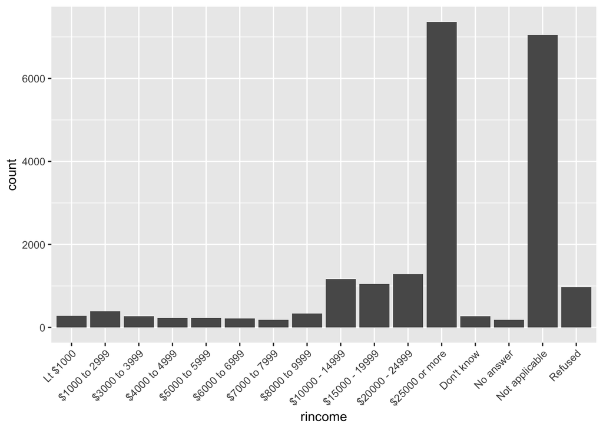

```r
income_lvl <- c("Lt $1000", "$1000 to 2999", "$3000 to 3999",
                "$4000 to 4999", "$5000 to 5999", "$6000 to 6999",
                "$7000 to 7999", "$8000 to 9999", "$10000 - 14999",
                "$15000 - 19999", "$20000 - 24999", "$25000 or more",
                "Don't know", "No answer", "Not applicable", "Refused")

gss_clean <- gss_cat %>%
  mutate(rincome = factor(rincome,
                          levels = income_lvl))

ggplot(gss_clean, aes(x = rincome))+
  geom_bar() +
  theme(axis.text.x = element_text(angle = 45, hjust = 1))
```

**ANSWER:** There area few issue with the bar chart. One, the labels on the x-axis are hard to read. Additionally, it does not appear sequentially and the answers that include `refused`, `don't know`, and `no answer` are mixed in with the numbers, so we want to make sure we reorder them so we can read the visualization.

### Exercise 2

What is the most common `relig` in this survey? What’s the most common `partyid`?

```r
gss_cat %>%
  group_by(relig) %>%
  count() %>%
  arrange(desc(n))
```

```
# A tibble: 15 × 2
# Groups:   relig [15]
   relig                       n
   <fct>                   <int>
 1 Protestant              10846
 2 Catholic                 5124
 3 None                     3523
 4 Christian                 689
 5 Jewish                    388
 6 Other                     224
 7 Buddhism                  147
 8 Inter-nondenominational   109
 9 Moslem/islam              104
10 Orthodox-christian         95
11 No answer                  93
12 Hinduism                   71
13 Other eastern              32
14 Native american            23
15 Don't know                 15
```

```r
gss_cat %>%
  group_by(partyid) %>%
  count() %>%
  arrange(desc(n))
```

```
# A tibble: 10 × 2
# Groups:   partyid [10]
   partyid                n
   <fct>              <int>
 1 Independent         4119
 2 Not str democrat    3690
 3 Strong democrat     3490
 4 Not str republican  3032
 5 Ind,near dem        2499
 6 Strong republican   2314
 7 Ind,near rep        1791
 8 Other party          393
 9 No answer            154
10 Don't know             1
```

**ANSWER:** The most common `relig` in this survey is Protestant, and the most common `partyid` is Independent.

### Exercise 3

Which `relig` does `denom` (denomination) apply to? Create a visualization to find out.

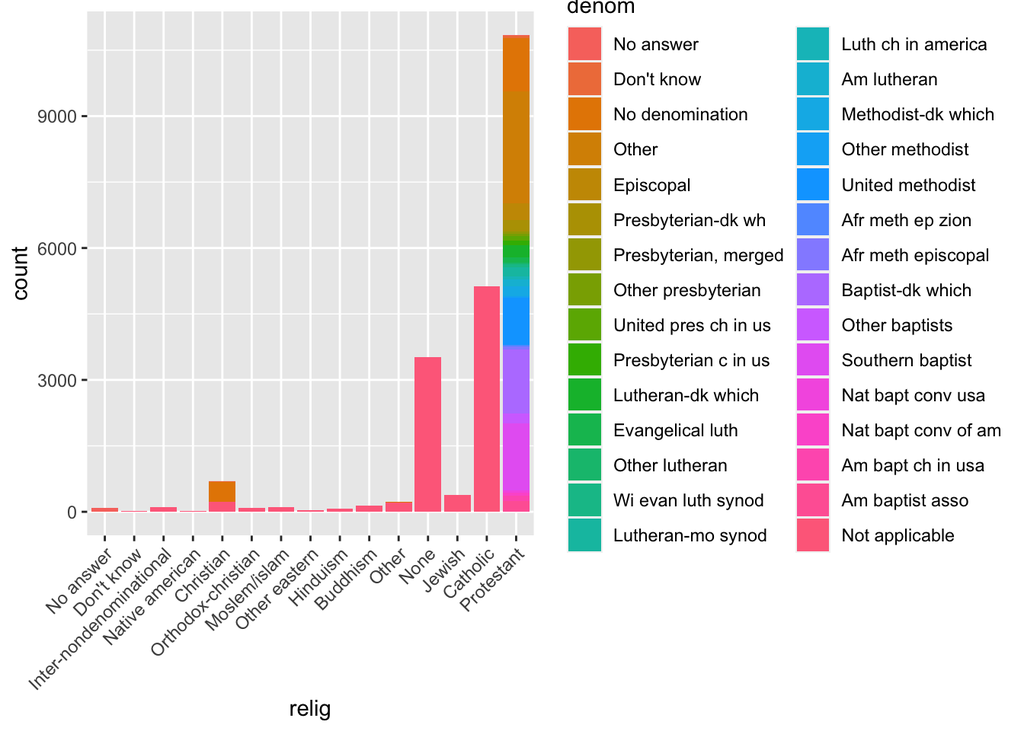

```r
ggplot(gss_cat, aes(x = relig, fill = denom)) +
  geom_bar() +
  theme(axis.text.x = element_text(angle = 45, hjust = 1))
```

**ANSWER:** According to the visualization, `denom` mainly applies to Protestant, and also Christian.

### Exercise 4

There are some suspiciously high numbers in `avg_tvhours` (mean or average of `tvhours`). Since the mean is not robust to outliers, it is not a good summary of this variable. Create a graphic similar to the one below, but use a more appropriate summary of `tvhours`.

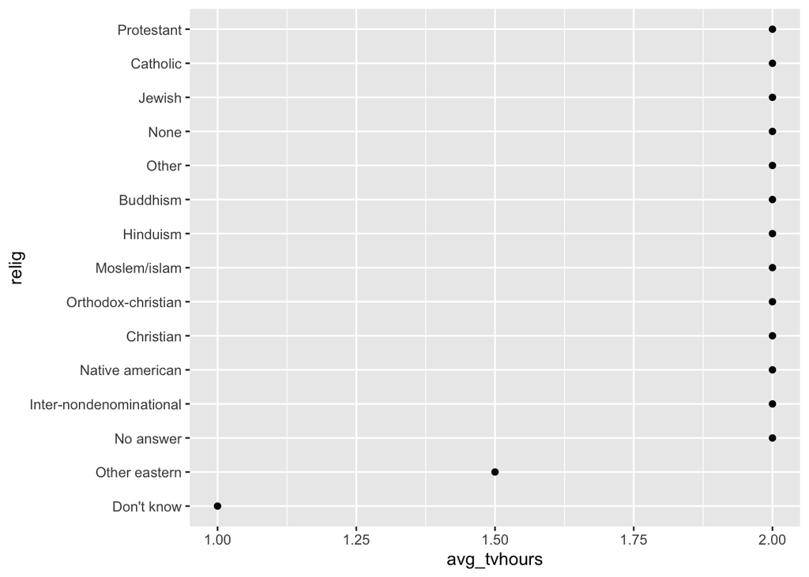

```r
# data wrangling
relig_summary <- gss_cat %>%
  group_by(relig) %>%
  summarise(
    age = median(age, na.rm = TRUE),
    avg_tvhours = median(tvhours, na.rm = TRUE),
    n = n()
  )

# bar plot
relig_summary %>%
  mutate(relig = fct_reorder(relig, avg_tvhours)) %>%
  ggplot(aes(avg_tvhours, relig)) +
    geom_point()
```

### Exercise 5

How have the proportions of people who identify as Democrat, Republican, and Independent changed over the time period from 2000 to 2014? Build a visualization to display this information. You should also write a few sentences to summarize the trends within the graphic.

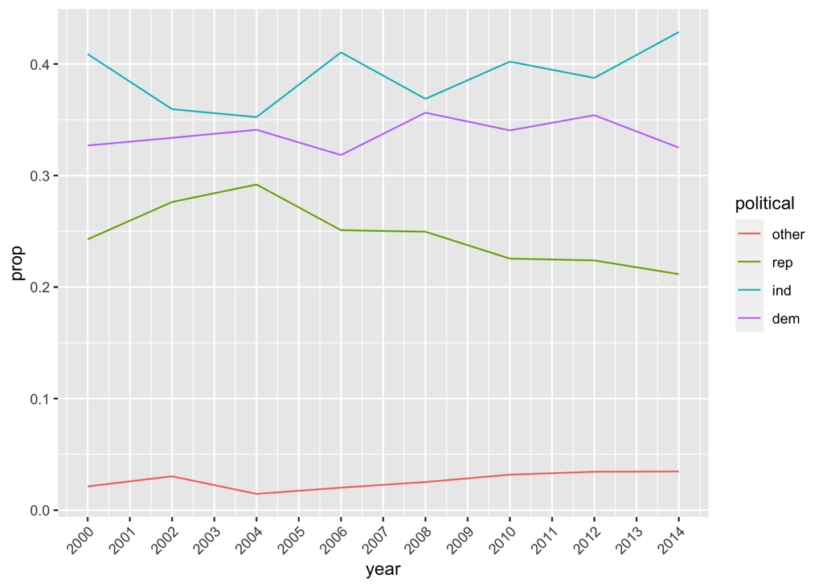

```r
gss_party <- gss_cat %>%
  mutate(political = fct_collapse(partyid,
                                other = c("No answer", "Don't know", "Other party"),
                                rep = c("Strong republican", "Not str republican"),
                                ind = c("Ind,near rep", "Independent", "Ind,near dem"),
                                dem = c("Not str democrat", "Strong democrat"))) %>%
  group_by(year) %>%
  mutate(count = n()) %>%
  group_by(year, political) %>%
  mutate(prop = n()/count)

gss_party %>%
  ggplot(aes(year, prop, color = political)) +
  geom_line() +
  scale_x_continuous(breaks = c(2000:2014)) +
  theme(axis.text.x = element_text(angle = 45, hjust = 1))
```

### Exercise 6

Demonstrate how to collapse `rincome` into a smaller set of categories.

```r
gss_income <- gss_cat %>%
  mutate(incomes = fct_collapse(rincome,
                                other = c("No answer", "Don't know", "Refused", "Not applicable"),
                                lower = c("Lt $1000", "$1000 to 2999", "$3000 to 3999", "$4000 to 4999"),
                                middle = c("$5000 to 5999", "$6000 to 6999", "$7000 to 7999", "$8000 to 9999"),
                                high = c("$10000 - 14999","$15000 - 19999", "$20000 - 24999", "$25000 or more")))

gss_income
```

```
# A tibble: 21,483 × 10
    year marital         age race  rincome   partyid relig denom tvhours incomes
   <int> <fct>         <int> <fct> <fct>     <fct>   <fct> <fct>   <int> <fct>
 1  2000 Never married    26 White $8000 to… Ind,ne… Prot… Sout…      12 middle
 2  2000 Divorced         48 White $8000 to… Not st… Prot… Bapt…      NA middle
 3  2000 Widowed          67 White Not appl… Indepe… Prot… No d…       2 other
 4  2000 Never married    39 White Not appl… Ind,ne… Orth… Not …       4 other
 5  2000 Divorced         25 White Not appl… Not st… None  Not …       1 other
 6  2000 Married          25 White $20000 -… Strong… Prot… Sout…      NA high
 7  2000 Never married    36 White $25000 o… Not st… Chri… Not …       3 high
 8  2000 Divorced         44 White $7000 to… Ind,ne… Prot… Luth…      NA middle
 9  2000 Married          44 White $25000 o… Not st… Prot… Other       0 high
10  2000 Married          47 White $25000 o… Strong… Prot… Sout…       3 high
# … with 21,473 more rows
```